# rOpenSci, Statistical Software, and the R Validation Hub

Mark Padgham

2020-09-21

## Background

[rOpenSci](https://ropensci.org) is an organization devoted to “transforming science through data, software and reproducibility.” One of rOpenSci’s focal activities is peer review of R packages which fall within one of several [focal categories](https://devguide.ropensci.org/policies.html#aims-and-scope). These categories notably exclude statistical software, which is arguably the reason for the entire R language. To redress this, rOpenSci have begun a [project](https://ropensci.org/blog/2019/07/15/expanding-software-review/) to expand our peer review system to encompass explicitly statistical software, funded by a grant from the Alfred P. Sloan Foundation.

Two of the primary goals for the project are to develop sets of standards for several sub-categories of statistical software, and to develop a suite of tools for the assessment of category-specific software. Many of these tools are intended to function automatically, and to provide overviews of software structure and function, as well as to automatically diagnose and provide information on errors, warnings, and other diagnostic messages issued during execution of software functions.

Two of these tools are similar in scope to both the [`riskmetric` package](https://www.pharmar.org/blog/2020/06/09/2020-06-02-riskmetric-intro-jun-2020/) and the [Risk Assessment Application](https://www.pharmar.org/blog/2020/08/05/2020-08-05-risk-assessment-application/). Similar to the goals of R Validation Hub, one of our aims is to automate as much as possible the production of a template for reporting on and reviewing software. Because our distinct aims and scope differ from the specific aims of the R Validation Hub, there is a great deal of complementarity rather than overlap in the two endeavours, which this blog post aims to highlight.

## Package Reporting

Our automated package assessment currently focusses on two main components, one of which, via a package currently called [`packgraph`](https://github.com/mpadge/packgraph), provides a templated high-level report on software structure and functionality. In current form, this reporting is largely based on analyses of function call graphs within the R code of a package, extending from the output of the [`pkgapi` package](https://github.com/r-lib/pkgapi). (Neither of these packages are currently on CRAN, so installing `packgraph` requires first running `remotes::intall_github("r-lib/pkgapi")`, followed by `remotes::install_github("mpadge/packgraph")`.)

The current implementation of [`packgraph`](https://github.com/mpadge/packgraph) provides an overview of package structure and inter-relationships between package functions, along with an optional interactive visualization of the network of function calls within a package, via the `pg_graph()` function. Function call networks are commonly divided among distinct clusters of locally inter-connected functions, with the resultant visualization using a different colour to visually distinguish each cluster. Applying this function to the [`riskmetric` package](https://github.com/pharmar/riskmetric) gives a static version of the actual interactive graphical result that looks something like the following image.

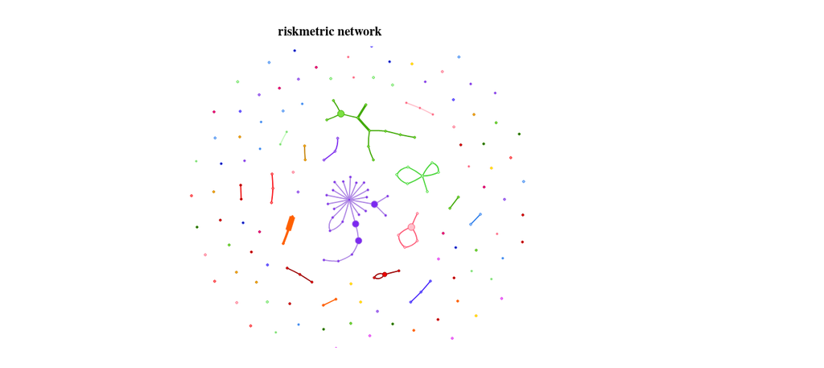

Each node of the network is a function, with sizes scaled by how many times that function is called. Each line reflects a call from one function to another, with a thickness scaled by numbers of calls between those two functions. The function at the centre of the purple star shape is the core `pkg_metric` function, with the long tail representing functions for processing errors and warnings. That graph provides an immediate visual representation of overall package structure, revealing in the case of the [`riskmetric`](https://github.com/pharmar/riskmetric) package a large number of effectively independent functions which are not directly called by other functions. Most of these isolated functions represent the various assessment metrics and associated caching procedures, which in turn reflect the modular design of the package, in which assessments, and the connections between these peripheral isolated functions, are controlled by the user rather than being hard-coded within the package.

Most packages have more defined clusters of interconnections which this interactive graphical output can help to explore and understand. The `pg_report()` function also generates a tabular summary of this function call network. By default, the `pg_report()` function only summarizes inter-relationships between exported functions of package, although setting `exported_only = FALSE` will yield a summary of inter-relationships between all functions of a package. The summary for the exported functions of the [`riskmetric`](https://github.com/pharmar/riskmetric) package looks something like the following.

```r
library (packgraph)
pkg_source <- "/<local>/<path>/<to>/riskmetric"
g <- pg_graph (pkg_source, plot = FALSE)
pg_report (g)
```

```
## ══ riskmetric
════════════════════════════════════════════════════════════════════════════════════════════════════════════════════════════════════════════════════════════════════════════════════════════════════════════════════════════════
##
## The package has 24 exported functions, and 155 non-exported funtions. The exported functions are structured into the following 3 primary clusters containing 2, 9 and 2 functions
##
##
## | cluster|  n|name       | num_params| num_doc_words| num_doc_lines| num_example_lines| centrality|
## |-------:|--:|:----------|----------:|-------------:|-------------:|-----------------:|----------:|
## |       1|  1|pkg_ref    |          2|           400|             9|                 0|          1|
## |       1|  2|as_pkg_ref |          2|            29|             7|                 0|         NA|
##
##
## | cluster|  n|name                        | num_params| num_doc_words| num_doc_lines| num_example_lines| centrality|
## |-------:|--:|:---------------------------|----------:|-------------:|-------------:|-----------------:|----------:|
## |       2|  1|assessment_error_empty      |          2|            48|             4|                 0|          2|
## |       2|  2|assess_has_bug_reports_url  |          2|            76|             0|                 1|         NA|
## |       2|  3|assess_has_maintainer       |          2|            45|             5|                 1|         NA|
## |       2|  4|assess_has_source_control   |          2|            53|             8|                 1|         NA|
## |       2|  5|assess_has_website          |          2|            46|            76|                 1|         NA|
## |       2|  6|assess_license              |          2|            42|            13|                 1|         NA|
## |       2|  7|assessment_error_as_warning |          3|            62|             8|                 0|         NA|
## |       2|  8|assessment_error_throw      |          3|            56|             9|                 0|         NA|
## |       2|  9|pkg_metric                  |          3|            87|             0|                 0|         NA|
##
##
## | cluster|  n|name            | num_params| num_doc_words| num_doc_lines| num_example_lines| centrality|
## |-------:|--:|:---------------|----------:|-------------:|-------------:|-----------------:|----------:|
## |       3|  1|all_assessments |          0|            57|             0|                 0|         NA|
## |       3|  2|pkg_assess      |          4|           162|             1|                 0|         NA|
##
## There are also 11 isolated functions:
##
##
## |  n|name                       | loc|
## |--:|:--------------------------|---:|
## |  1|assess_covr_coverage       |   3|
## |  2|assess_downloads_1yr       |   3|
## |  3|assess_export_help         |   3|
## |  4|assess_has_news            |   3|
## |  5|assess_has_vignettes       |   3|
## |  6|assess_last_30_bugs_status |   3|
## |  7|assess_news_current        |   3|
## |  8|coverage                   |   3|
## |  9|metric_score               |   3|
## | 10|pkg_score                  |   3|
## | 11|summarize_scores           |   3|
##
## ── Documentation of non-exported functions ───────────────────────────────────────────────────────────────────────────────────────────────────────────────────────────────────────────────────────────────────────────────────────────────────
##
##
## |value  | doclines| cmtlines|
## |:------|--------:|--------:|
## |mean   |      4.5|      0.6|
## |median |      2.0|      0.0|
```

## Package Testing

Package reporting is primarily intended as an aid to reviewers of packages to be submitted to our peer review system. We are also developing tools to aid package developers, foremost among which is a package for automatic testing of statistical software called [`autotest`](https://github.com/ropenscilabs/autotest). The package implements a form of “mutation testing”. In contrast to common interpretations of this phrase as referring to [mutation of underlying code](https://en.wikipedia.org/wiki/Mutation_testing), the [`autotest` package](https://github.com/ropenscilabs/autotest) mutates the objects which are passed to the functions of a package, and so may be considered a form of [“mutation fuzzing”](https://www.fuzzingbook.org/html/MutationFuzzer.html), where “fuzzing” refers to general practices of throwing random objects at software to test its robustness.

[`autotest`](https://github.com/ropenscilabs/autotest) extracts all example code for a package, parses those examples to examine all objects being thrown at the package’s functions, and then mutates those objects to assess what happens. The package will ultimately have a workflow entirely compatible with [`riskmetric`](https://github.com/pharmar/riskmetric), and so will act as a plug-in extension to that package, with automatic tests themselves being user-controlled and modular.

Current tests include mutations of value, size, class, and other structural properties of inputs. Mutations may be expected to be acceptable – such as a documented example which includes some function `myfn (x = TRUE)`, which would be expected to also work with `x = FALSE` – or they may be expected to generate warnings or errors, such as in response to passing a value of `x = "a"` to that example. Robust software should accept all appropriate mutations of inputs, while rejecting all inappropriate mutations. [`autotest`](https://github.com/ropenscilabs/autotest) only produces output where expectations are not met.

As described above, the package is intended as developer tool, because all packages to be submitted to our peer review system will be expected to yield clean results when submitted to [`autotest`](https://github.com/ropenscilabs/autotest). The package will be able to be applied by anyone developing packages from the moment they implement their first exported function. The hope is then that ongoing usage of the package throughout the development of any statistical (or other) software will enhance its robustness, and reduce any chance of unexpected behaviour in response to inputs which developers may not otherwise have anticipated.

Finally, the [`autotest`](https://github.com/ropenscilabs/autotest) package will also form part of our reporting system, with its output forming part of our initial reports provided to reviewers. Most importantly, we intend to implement mechanisms to enable users to control which tests are run on any particular package, and to oblige those intending to submit to our system to provide descriptive justifications of why particular tests may have been switched off. These textual explanations will then also form part of our initial reports, enabling reviewers to understand not only which kinds of tests package developers deem inappropriate for their software, but more importantly why.

### autotesting the riskmetric package

What happens when [`autotest`](https://github.com/ropenscilabs/autotest) is applied to the [`riskmetric`](https://github.com/pharmar/riskmetric) package? The main function that does the work is [`autotest_package()`](https://ropenscilabs.github.io/autotest/reference/autotest_package.html), as demonstrated with the following code:

```r
library (autotest)
system.time (
    x <- autotest_package ("/<local>/<path>/<to>/riskmetric")
    )
```

```
## Loading riskmetric
##    user  system elapsed
##   3.462   0.113   5.337
```

And you can see that the function takes a few seconds to run. The function returns a [`tibble`](https://tibble.tidyverse.org) object, each row of which represents a test expectation which was not fulfilled. The package also implements a `summary` method for these objects an edited part of which looks like this:

```r
summary (x)
```

```
## autotesting package [riskmetric, v0.1.0.9001] generated 13 rows of output of the following types:
##      0 errors
##      13 warnings
##      0 messages
##      0 other diagnosticss
##
## The output includes 13 functions which have no documented examples:
##     1. all_assessments
##     2. as_pkg_ref
##     3. assessment_error_as_warning
##     4. assessment_error_empty
##     5. assessment_error_throw
##     6. coverage
##     7. metric_score
##     8. pkg_assess
##     9. pkg_metric
##     10. pkg_ref
##     11. score_error_default
##     12. score_error_NA
##     13. score_error_zero
##
##     git hash for package as analysed here:
##     [fa5a36e586d8b9c160e876a1dfd1bc32497ff428]
```

The result contained no errors or diagnostic messages, and 13 warnings for functions which have no documented examples. These are considered as warnings, because the [`autotest`](https://github.com/ropenscilabs/autotest) package primarily works by scraping example code for each function, so functions with no examples can not be tested. A clean [`autotest`](https://github.com/ropenscilabs/autotest) result could thus be achieved for the [`riskmetric`](https://github.com/pharmar/riskmetric) package by providing example code for each of those listed functions (and ensuring that the resultant [`autotest`](https://github.com/ropenscilabs/autotest)-ing of those examples generated no additional output).

## Package Standards and Peer Review

In addition to the automated tools described in the preceding two sections, a large part of the project is devoted to devising standards for statistical software. We have identified 11 primary categories which we aim to consider as within scope for submission, and for which we will develop category-specific standards. Full details of the categories and standards can be seen on the primary [“living book”](https://ropenscilabs.github.io/statistical-software-review-book/index.html) of the project, which describes the current categories of:

1. Bayesian and Monte Carlo Routines
2. Dimensionality Reduction, Clustering, and Unsupervised Learning
3. Machine Learning
4. Regression and Supervised Learning
5. Probability Distributions
6. Wrapper Packages
7. Networks
8. Exploratory Data Analysis (EDA) and Summary Statistics
9. Workflow Support
10. Spatial Analyses
11. Time Series Analyses

The tools described above aim to make the task of reviewing packages as easy as possible. The category-specific standards aim to ensure that software accepted as part of our system is of the highest possible quality. One of the primary tasks of reviewers will be to assess software against these standards. We have currently developed general standards for statistical software, along with category-specific versions for [five of these categories](https://ropenscilabs.github.io/statistical-software-review-book/standards.html). We have released an initial call for “soft submissions” within those categories, which will ultimately be considered as formal submissions to our system, yet are also intended to help guide and improve our process of peer review. We invite any developers reading this blog who might be interested in submitting a statistical software package for peer review to contact us (Mark Padgham mark@ropensci.org and/or Noam Ross ross@ecohealthalliance.org) about a “soft submission”. Your contribution would help improve the quality of our system, while our assessments and reviews would help improve the quality of your software. We look forward to any contributions to help improve our system for peer review of statistical software, and ultimately for helping to improve the quality of statistical software in R.